# Assignment 3 (Big Data Technologies)

Name: Avinash Pandey

ID: 46139001

## Analysis of medical publications about COVID-19

With the current pandemic ongoing, the situation has led to trigger an unpredictable number of medical researches with the motive for finding treatments as well as vaccines as early as possible. The current circumstances have also directed to make efforts in gathering research publications along with the retrieval of text information in order to do text mining. Here in this assessment, we will be using a part of most commonly implemented resource of this type: CORD-19. To add to that, this specific resource can be available through various outlets, one of the most popular is Kaggle and the link is given below:

https://www.kaggle.com/allen-institute-for-ai/CORD-19-research-challenge

Initially, we will be making usage of Kaggle's subset data gathered in the file named as "metadata.csv" that is in csv format.

## Reading the data set

```python
#importing all libraries
import pandas as pd
import numpy as np
from tqdm import tqdm
import json
import os
import matplotlib.pyplot as plt
import seaborn as sns
import nltk
import re
from nltk.corpus import stopwords
from nltk.stem.wordnet import WordNetLemmatizer
from nltk.tokenize import word_tokenize
import collections
import wordcloud
from spacy.lang.en.stop_words import STOP_WORDS
from scipy.spatial.distance import cdist
from sklearn.feature_extraction.text import CountVectorizer
from sklearn.feature_extraction.text import TfidfVectorizer
from sklearn.decomposition import LatentDirichletAllocation
from sklearn.decomposition import PCA
from sklearn.model_selection import GridSearchCV
from sklearn.manifold import TSNE
from sklearn.cluster import KMeans
import spacy

from bokeh.models import ColumnDataSource, HoverTool
from bokeh.plotting import figure,show,output_notebook
import pyLDAvis
import pyLDAvis.gensim_models
from sentence_transformers import SentenceTransformer
import warnings
import pprint

pd.set_option('display.max_columns',None)
warnings.filterwarnings('ignore')
%matplotlib inline
```

```python
#putting the data into data frame
meta_d = pd.read_csv("D:/Learning/Big Data Technologies/Assignment3/metadata.csv", sep=",")
meta_d.head(5)
```

|  | cord_uid | sha | source_x | title | doi | pmcid | pubmed_id | license | abstract | publish_time | authors | journal | mag_id | who_covidence_id | arxiv_id | pdf_json_files | pmc_json_files | url | s2_id |
| --- | --- | --- | --- | --- | --- | --- | --- | --- | --- | --- | --- | --- | --- | --- | --- | --- | --- | --- | --- |
| 0 | ug7v899j | d1aafb70c066a2068b02786f8929fd9c900897fb | PMC | Clinical features of culture-proven Mycoplasma... | 10.1186/1471-2334-1-6 | PMC35282 | 11472636 | no-cc | OBJECTIVE: This retrospective chart review des... | 2001-07-04 | Madani, Tariq A; Al-Ghamdi, Aisha A | BMC Infect Dis | NaN | NaN | NaN | document_parses/pdf_json/d1aafb70c066a2068b027... | document_parses/pmc_json/PMC35282.xml.json | https://www.ncbi.nlm.nih.gov/pmc/articles/PMC3... | NaN |
| 1 | 02tnwd4m | 6b0567729c2143a66d737eb0a2f63f2dce2e5a7d | PMC | Nitric oxide: a pro-inflammatory mediator in l... | 10.1186/rr14 | PMC59543 | 11667967 | no-cc | Inflammatory diseases of the respiratory tract... | 2000-08-15 | Vliet, Albert van der; Eiserich, Jason P; Cros... | Respir Res | NaN | NaN | NaN | document_parses/pdf_json/6b0567729c2143a66d737... | document_parses/pmc_json/PMC59543.xml.json | https://www.ncbi.nlm.nih.gov/pmc/articles/PMC5... | NaN |
| 2 | ejv2xln0 | 06ced00a5fc04215949aa72528f2eeaae1d58927 | PMC | Surfactant protein-D and pulmonary host defense | 10.1186/rr19 | PMC59549 | 11667972 | no-cc | Surfactant protein-D (SP-D) participates in th... | 2000-08-25 | Crouch, Erika C | Respir Res | NaN | NaN | NaN | document_parses/pdf_json/06ced00a5fc04215949aa... | document_parses/pmc_json/PMC59549.xml.json | https://www.ncbi.nlm.nih.gov/pmc/articles/PMC5... | NaN |
| 3 | 2b73a28n | 348055649b6b8cf2b9a376498df9bf41f7123605 | PMC | Role of endothelin-1 in lung disease | 10.1186/rr44 | PMC59574 | 11686871 | no-cc | Endothelin-1 (ET-1) is a 21 amino acid peptide... | 2001-02-22 | Fagan, Karen A; McMurtry, Ivan F; Rodman, David M | Respir Res | NaN | NaN | NaN | document_parses/pdf_json/348055649b6b8cf2b9a37... | document_parses/pmc_json/PMC59574.xml.json | https://www.ncbi.nlm.nih.gov/pmc/articles/PMC5... | NaN |
| 4 | 9785vg6d | 5f48792a5fa08bed9f56016f4981ae2ca6031b32 | PMC | Gene expression in epithelial cells in respons... | 10.1186/rr61 | PMC59580 | 11686888 | no-cc | Respiratory syncytial virus (RSV) and pneumoni... | 2001-05-11 | Domachowske, Joseph B; Bonville, Cynthia A; Ro... | Respir Res | NaN | NaN | NaN | document_parses/pdf_json/5f48792a5fa08bed9f560... | document_parses/pmc_json/PMC59580.xml.json | https://www.ncbi.nlm.nih.gov/pmc/articles/PMC5... | NaN |

```python
meta_d.info()
```

```
<class 'pandas.core.frame.DataFrame'>
RangeIndex: 768929 entries, 0 to 768928
Data columns (total 19 columns):
 #   Column            Non-Null Count   Dtype
---  ------            --------------   -----
 0   cord_uid          768929 non-null  object
 1   sha               240689 non-null  object
 2   source_x          768929 non-null  object
 3   title             768555 non-null  object
 4   doi               380270 non-null  object
 5   pmcid             249436 non-null  object
 6   pubmed_id         330306 non-null  object
 7   license           768929 non-null  object
 8   abstract          569842 non-null  object
 9   publish_time      768703 non-null  object
 10  authors           751296 non-null  object
 11  journal           721462 non-null  object
 12  mag_id            0 non-null       float64
 13  who_covidence_id  365653 non-null  object
 14  arxiv_id          9487 non-null    object
 15  pdf_json_files    240689 non-null  object
 16  pmc_json_files    197394 non-null  object
 17  url               404934 non-null  object
 18  s2_id             710660 non-null  float64
dtypes: float64(2), object(17)
memory usage: 111.5+ MB
```

## Task 1- What is the distribution of journals per source?

First of all, we will be identifying the 10 most frequent journals.

```python
meta_df = pd.DataFrame({'ID':meta_d["cord_uid"], 'Source': meta_d["source_x"], 'License':meta_d["license"],'Journal': meta_d["journal"],'Title': meta_d["title"], 'Abstract':meta_d["abstract"],'Authors':meta_d["authors"] })
meta_df.head(5)
```

|  | ID | Source | License | Journal | Title | Abstract | Authors |
| --- | --- | --- | --- | --- | --- | --- | --- |
| 0 | ug7v899j | PMC | no-cc | BMC Infect Dis | Clinical features of culture-proven Mycoplasma... | OBJECTIVE: This retrospective chart review des... | Madani, Tariq A; Al-Ghamdi, Aisha A |
| 1 | 02tnwd4m | PMC | no-cc | Respir Res | Nitric oxide: a pro-inflammatory mediator in l... | Inflammatory diseases of the respiratory tract... | Vliet, Albert van der; Eiserich, Jason P; Cros... |
| 2 | ejv2xln0 | PMC | no-cc | Respir Res | Surfactant protein-D and pulmonary host defense | Surfactant protein-D (SP-D) participates in th... | Crouch, Erika C |
| 3 | 2b73a28n | PMC | no-cc | Respir Res | Role of endothelin-1 in lung disease | Endothelin-1 (ET-1) is a 21 amino acid peptide... | Fagan, Karen A; McMurtry, Ivan F; Rodman, David M |
| 4 | 9785vg6d | PMC | no-cc | Respir Res | Gene expression in epithelial cells in respons... | Respiratory syncytial virus (RSV) and pneumoni... | Domachowske, Joseph B; Bonville, Cynthia A; Ro... |

```python
count = meta_df['Journal'].value_counts()[:10].index.tolist()
count
```

```
['PLoS One',
 'bioRxiv',
 'BMJ',
 'Sci Rep',
 'Int J Environ Res Public Health',
 'Nature',
 'Lancet',
 'Int. j. environ. res. public health (Online)',
 'Cureus',
 'Viruses']
```

```python
meta_df['Journal'].value_counts().to_frame()
```

|  | Journal |
| --- | --- |
| PLoS One | 7610 |
| bioRxiv | 6489 |
| BMJ | 6097 |
| Sci Rep | 4137 |
| Int J Environ Res Public Health | 3995 |
| ... | ... |
| International Journal of Genomics | 1 |
| The International Journal of Press/Politics | 1 |
| Hematol Rev | 1 |
| Urban Water Journal | 1 |
| Pflegewissen Pneumologie | 1 |

43027 rows × 1 columns

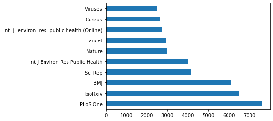

```python
datap = meta_df['Journal'].value_counts()[:10].plot(kind='barh')
```

After the analysis of data fetched, the top 10 journals are plotted in the above bar chart diagram.

Since some of the publications have multiple sources, we will be using the first source only that is illustrated below.

```python
meta_df['First Source'] = meta_df['Source'].apply(lambda x: x.split(";")[0])
meta_df.head(5)
```

|  | ID | Source | License | Journal | Title | Abstract | Authors | First Source |
| --- | --- | --- | --- | --- | --- | --- | --- | --- |
| 0 | ug7v899j | PMC | no-cc | BMC Infect Dis | Clinical features of culture-proven Mycoplasma... | OBJECTIVE: This retrospective chart review des... | Madani, Tariq A; Al-Ghamdi, Aisha A | PMC |
| 1 | 02tnwd4m | PMC | no-cc | Respir Res | Nitric oxide: a pro-inflammatory mediator in l... | Inflammatory diseases of the respiratory tract... | Vliet, Albert van der; Eiserich, Jason P; Cros... | PMC |
| 2 | ejv2xln0 | PMC | no-cc | Respir Res | Surfactant protein-D and pulmonary host defense | Surfactant protein-D (SP-D) participates in th... | Crouch, Erika C | PMC |
| 3 | 2b73a28n | PMC | no-cc | Respir Res | Role of endothelin-1 in lung disease | Endothelin-1 (ET-1) is a 21 amino acid peptide... | Fagan, Karen A; McMurtry, Ivan F; Rodman, David M | PMC |
| 4 | 9785vg6d | PMC | no-cc | Respir Res | Gene expression in epithelial cells in respons... | Respiratory syncytial virus (RSV) and pneumoni... | Domachowske, Joseph B; Bonville, Cynthia A; Ro... | PMC |

Here in this part, we have selected each journal source and tried displaying the distribution of publications in each source.

```python
data_edit = meta_df[meta_df["Journal"].isin(count)]
data_journal = data_edit.groupby(['First Source','Journal'])['ID'].count().reset_index()
data_journal["ID"] = np.log(data_journal["ID"])
```

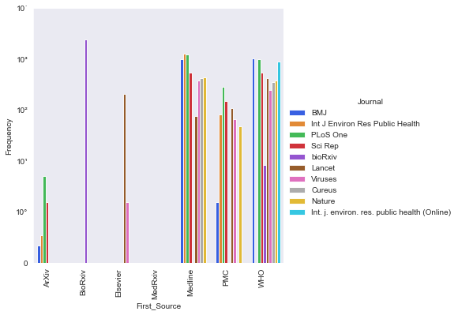

```python
sns.set_style("dark")
data_plot = sns.catplot(kind="bar",
                x="First Source", y="ID", hue="Journal", data=data_journal,
 palette="bright", alpha=.9, height=5)
data_plot.set_axis_labels("First_Source", "Frequency")
data_plot.set_xticklabels( rotation=90, horizontalalignment='right',
                      fontweight='light')
data_plot.set_yticklabels(["0", "10\u00b0", "10¹", "10\u00b2", "10\u00b3", "10\u00b4"])
```

#### Interpretations:

i) We have only selected top 10 journals from the data for plotting.

ii) For each of the journal source, we calculated the number of journals for all the publications within that source.

iii) Following to that, grouping of the data has been done along with the first source and Journal.

iv) Likewise, we calculated the journals using ID as count.

v) Lastly, we made usage of log transformation in y axis and the chart is illustrated as above.

## Task 2- What are the main clusters?

Here in this part, we will be fetching the text from the 'abstracts' in given data set for clustering and visualisation process. For clustering the data set, we will be making use of KMeans clustering algorithm. K-means clustering is defined as an approach for vector quantization process, initially from signal processing, that points to divide n observations to k clusters where each of the consideration applies to cluster with the adjacent mean, performing as a model of the collection.

```python
import spacy
from spacy.lang.en.stop_words import STOP_WORDS
import en_core_sci_lg
import string
import nltk, string, numpy
from nltk.stem.snowball import SnowballStemmer
nltk.download('stopwords')
stem = nltk.stem.porter.PorterStemmer()
lem = nltk.stem.WordNetLemmatizer()
stopwords = nltk.corpus.stopwords.words('english')

nltk.download('punkt')
nltk.download('wordnet')

stem = SnowballStemmer("english")
meta_df = meta_df[meta_df["Abstract"].notna()]
```

```python
from sklearn.feature_extraction.text import CountVectorizer
meta_df = meta_df.sample(6000, random_state=0)
```

```python
from sklearn import metrics
from scipy.spatial.distance import cdist
meta_df["Journal"] = meta_df["Journal"].astype('category').cat.codes
meta_df["Authors"] = meta_df["Authors"].astype('category').cat.codes
meta_df["First Source"] = meta_df["First Source"].astype('category').cat.codes
meta_df["License"] = meta_df["License"].astype('category').cat.codes
```

#### Vectorization

For the vectorization of data, clustering approach has been selected depending on the context of 'abstract'.

```python
def Stem_Tok(tokens):
    return [stem.stem(token) for token in tokens]
remove_punct = dict((ord(punct), None) for punct in string.punctuation)

def Stem_Norm(text):
    return Stem_Tok(nltk.word_tokenize(text.lower().translate(remove_punct)))

def Lem_Tok(tokens):
    return [lem.lemmatize(token) for token in tokens]
remove_punct = dict((ord(punct), None) for punct in string.punctuation)

def Lem_Norm(text):
    return Lem_Tok(nltk.word_tokenize(text.lower().translate(remove_punct)))

count_vect = CountVectorizer(max_df = 0.8, max_features = 10000, tokenizer=Lem_Norm, stop_words='english')
vect_tfidf = count_vect.fit_transform(meta_df["Abstract"].apply(lambda x: np.str_(x)))
```

```python
tfidf_vector = []
for tf_list in vect_tfidf.toarray():
  tfidf_vector.append(sum(tf_list))
meta_df['VectsData'] = tfidf_vector
meta_df[["Journal", "Authors", "First Source", "License", "VectsData"]].head()
```

|  | Journal | Authors | First Source | License | VectsData |
| --- | --- | --- | --- | --- | --- |
| 694664 | 1947 | 5159 | 4 | 5 | 155 |
| 597660 | 1882 | 1918 | 4 | 3 | 264 |
| 235139 | 2117 | 127 | 6 | 15 | 128 |
| 48233 | 782 | 1984 | 5 | 14 | 96 |
| 238251 | 566 | 2663 | 6 | 15 | 72 |

```python
pca_val = PCA(n_components = 0.97, random_state=90)
pca_val.fit(meta_df[["Journal", "Authors", "First Source", "License", "VectsData"]])
scores_pca_val = pca_val.transform(meta_df[["Journal", "Authors", "First Source", "License", "VectsData"]])

distortions_val = []
K = range(2, 30)
for j in K:
  kmeans_pca_val = KMeans(n_clusters=j, algorithm= 'auto', init="k-means++", n_init=j, random_state=0)
  kmeans_pca_val.fit(scores_pca_val)
  distortions_val.append(sum(np.min(cdist(scores_pca_val, kmeans_pca_val.cluster_centers_, 'euclidean'), axis=1)) / meta_df.shape[0])
```

```python
print(distortions_val)
```

```
[1296.334543421139, 1110.1536111846933, 942.4399715065343, 830.4126697794446, 740.5251220458006, 690.3701987040058, 647.5592161346224, 610.4081955248182, 574.4581120118297, 542.8278501569578, 514.9440669798781, 493.67235345577535, 474.034755783595, 456.7686141915664, 443.57170421158804, 431.34237179…
```

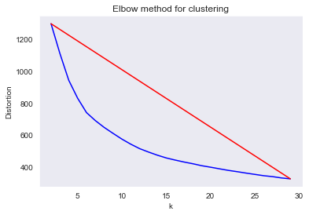

```python
from sklearn.cluster import KMeans
X_var = [K[0], K[-1]]
Y_var = [distortions_val[0], distortions_val[-1]]

#plotting the elbow method
plt.plot(K, distortions_val, 'b-')
plt.rcParams["figure.figsize"] = (7,3)
plt.plot(X_var, Y_var, 'r')
plt.title("Elbow method for clustering")
plt.xlabel("k")
plt.ylabel("Distortion")
plt.show()
```

#### Running K-means algorithm

```python
k = 20
kmeans_val = KMeans(n_clusters=k, random_state=45)
y_pred_val = kmeans_val.fit_predict(scores_pca_val)
meta_df['y'] = y_pred_val
```

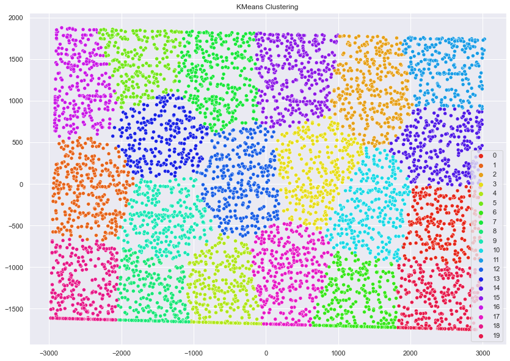

```python
sns.set(rc={'figure.figsize':(14,10)})

palette_val = sns.hls_palette(20, s=.8, l=.5)

plt.title('KMeans Clustering')
sns.scatterplot(scores_pca_val[:,0], scores_pca_val[:,1], legend = 'full', palette=palette_val, hue=y_pred_val)
plt.show()
```

#### Interpretations:

i) With the usage of KMeans algorithm, we built the plot for 20 clusters from the data set.

iii) Likewise, the value obtained along with the PCA reduced data facilitate us with the important data for the creation of clusters.

## Task 3 - For each cluster, what are the most representative words?

For accomplishing this task, we will be creating a word cloud for each of the clusters in such a way that size of each word determines the significance of the specific word in parallel cluster. Similarly, we will also be removing stopwords and other possible errors for cleaning the data.

```python
from wordcloud import WordCloud
def cleaned(txt):
  w = []
  regex_s = re.sub(r"[,.;@#?!&$]+", ' ', txt)
  regex_s = re.sub(r"\s+", ' ', regex_s)
  for word in regex_s.split():
    if word not in stopwords:
      w.append(lemma.lemmatize(word))
  return w

clust_n = 0
word_df = meta_df[meta_df["y"] == clust_n]
lemma = WordNetLemmatizer()
rep_words = [cleaned(x) for x in word_df["Abstract"]]
auth_words = []
for rep_list in rep_words:
  for rep_word in rep_list:
    auth_words.append(rep_word)
```

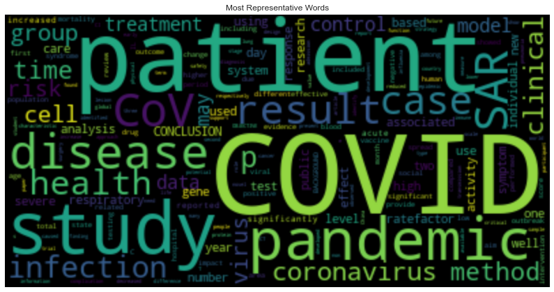

```python
w_c = WordCloud(collocations = False, background_color = 'black').generate(" ".join(auth_words))
plt.imshow(w_c, interpolation='gaussian')
plt.axis("off")
plt.title('Most Representative Words')
plt.show()
```

#### Interpretations:

i) Here, we selected the cluster by adjusting the value of cluster_n variable.

ii) Likewise, we have taken significant data from 'Abstract' that fits in cluster.

iii) After the selection of words, they are evaluated for punctuations as well as stop words. Then, we make usage of the words that passed the selection for the creation of word cloud.

iv) Furthermore, frequency has been taken as a measure for calculating significance of a word in above word cloud.

## Task 4 - What are the most common topics?

Here in this task, we will be conducting a topic modelling for identifying the major topics discussed in the abstracts. For accomplish this task, we have made usage of Gensim library that is a open source Python library that facilitates us for visualialising documents in form of semantic vectors as effectively as possible. Also, the implemented results are illustrated properly in the charts below.

```python
import gensim.corpora as corpora
import gensim
from gensim.models import LdaMulticore, CoherenceModel, Phrases, LdaModel
import time
l = WordNetLemmatizer()
rep_w = [cleaned(x) for x in meta_df["Abstract"]]
dict = gensim.corpora.Dictionary(rep_words)
dt_matrix = [dict.doc2bow(doc) for doc in rep_words]
```

```python
def comp_coherent_val(corp, dict, k):
    print(k)
    lda_mod = gensim.models.LdaMulticore(corpus=corp,
                                           id2word=dict,
                                           num_topics=k,
                                           random_state=99,
                                           chunksize=99,
                                           passes=10)

    coherent_mod_lda = gensim.models.CoherenceModel(model=lda_mod, texts=rep_words, dictionary=dict, coherence='c_v')
    return coherent_mod_lda.get_coherence()


top_range = range(3, 10, 1)
score_l = {}
for k in top_range:
  cv = comp_coherent_val(corp=dt_matrix, dict=dict, k=k)
  score_l[k] = cv
print(score_l)
```

```
3
4
5
6
7
8
9
{3: 0.3420137114537158, 4: 0.342676325220339, 5: 0.3567966419509051, 6: 0.36760406048428096, 7: 0.34147667310779345, 8: 0.3631530790072462, 9: 0.3621096540120448}
```

```python
score_l={3: 0.3420137114537158, 4: 0.342676325220339, 5: 0.3567966419509051, 6: 0.36760406048428096, 7: 0.34147667310779345, 8: 0.3631530790072462, 9: 0.3621096540120448}
```

```
<BarContainer object of 7 artists>
```

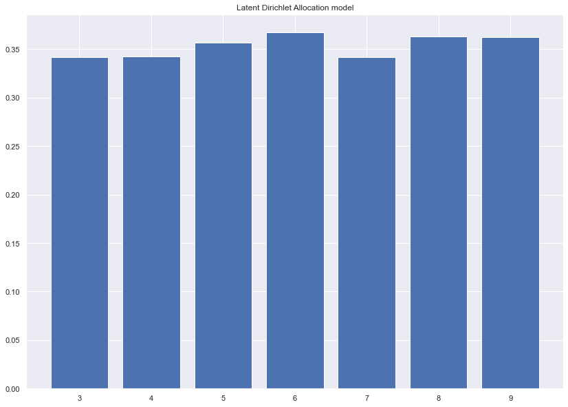

```python
names_var = list(score_l.keys())
values_var = list(score_l.values())
plt.title("Latent Dirichlet Allocation model")
plt.bar(range(len(score_l)), values_var, tick_label=names_var)
```

```python
lda_mod = gensim.models.LdaMulticore(corpus=dt_matrix,
            id2word=dict, chunksize=99, num_topics=k,
            random_state=99, passes=10)
print(lda_mod.print_topics())
```

```
[(0, '0.008*"COVID-19" + 0.007*"The" + 0.006*"patient" + 0.006*"vaccine" + 0.005*"=" + 0.004*"case" + 0.004*"symptom" + 0.004*"LUS" + 0.003*"0" + 0.003*"study"'), (1, '0.010*"The" + 0.009*"COVID-19" + 0.006*"patient" + 0.005*"disease" + 0.005*"state" + 0.004*"study" + 0.004*"0" + 0.004*"case" + 0.00…
```

```python
lda_mod.log_perplexity(dt_matrix)
```

```
-8.472595923325484
```

#### Interpretations:

iii) Likewise, the k value of topic 6 yields the highest coherence score and thus, justifies to be the excellent.

iv) For checking the model to be good enough for performing topic modelling, we need to check the perplexity score of the model. As we know, a model is better if there is a lower score, we have got the score of -8.472 stating that this model is good.

## Task 5 - What are the most common topics in each cluster?

For accomplishing this task, we will make usage of information fetched from earlier tasks for characterising the topics in each of the clusters. Likewise, after the interpretation is done, we will also answer to few questions illustrated as below.

```python
doc_k = list(meta_df.index)
doc_top = {}
for doc_id in range(len(dt_matrix)):
    doc_b = dt_matrix[doc_id]
    doc_tops = lda_mod.get_document_topics(doc_b, 0)
    tmp = []
    for topic_id, topic_prob in doc_tops:
        tmp.append(topic_prob)
    doc_top[doc_k[doc_id]] = tmp


new_data = pd.DataFrame.from_dict(doc_top, orient='index')
top_col = ['topic_' + str(i) for i in range(0, 9)]
new_data.columns = top_col
new_data['Abstract'] = (meta_df['Abstract'])

def f_top(row):
    if (row.loc[row>0.9]).any():
        return row.loc[row>0.9].index[0]
    else:
        return None

def f_prop(row):
    if (row.loc[row>0.9]).any():
        return row.loc[row>0.9].values[0]
    else:
        return None

new_data['Topic'] = new_data.loc[:, new_data.columns !='Abstract'].apply(f_top, axis = 1)
new_data['Propensity'] = new_data.iloc[:, 0:9].apply(f_prop, axis = 1)
new_data.drop(columns=new_data.columns[:10], inplace=True)
display(new_data.head())
```

|  | Topic | Propensity |
| --- | --- | --- |
| 694664 | topic_7 | 0.988293 |
| 597660 | topic_4 | 0.995597 |
| 235139 | topic_0 | 0.994887 |
| 48233 | topic_6 | 0.994370 |
| 238251 | topic_3 | 0.996443 |

```python
output_df = new_data.join(meta_df)
output_df.head()
```

|  | Topic | Propensity | ID | Source | License | Journal | Title | Abstract | Authors | First Source | VectsData | y |
| --- | --- | --- | --- | --- | --- | --- | --- | --- | --- | --- | --- | --- |
| 694664 | topic_7 | 0.988293 | vof858hp | Medline; PMC | 5 | 1947 | The impact of the coronavirus disease 2019 pan... | BACKGROUND: Daily moderate-to-vigorous physica... | 5159 | 4 | 155 | 14 |
| 597660 | topic_4 | 0.995597 | 8adx8ejg | Medline; PMC | 3 | 1882 | Evaluation of a Social Media Campaign in Saska... | BACKGROUND: The beginning of the COVID-19 pand... | 1918 | 4 | 264 | 13 |
| 235139 | topic_0 | 0.994887 | vpg6itzq | WHO | 15 | 2117 | Estimation of the Actual Incidence of Coronavi... | Following the first report of the coronavirus ... | 127 | 6 | 128 | 1 |
| 48233 | topic_6 | 0.994370 | q6cbcip4 | PMC | 14 | 782 | The Rise of School Choice: Leaving No Child Be... | The publication of the Coleman Report (1966), ... | 1984 | 5 | 96 | 4 |
| 238251 | topic_3 | 0.996443 | czcr4vxf | WHO | 15 | 566 | The COVID-19 exams fiasco across the UK: four ... | All four UK and devolved governments performed... | 2663 | 6 | 72 | 4 |

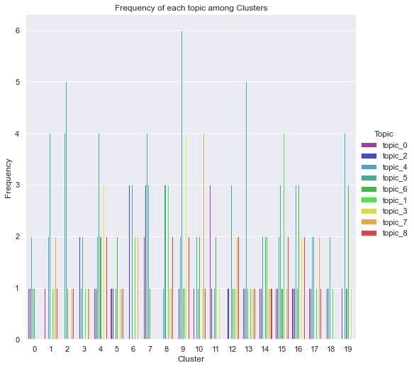

```python
out_df = output_df.groupby(["y", "Topic"])["Title"].count().reset_index()
out_df.columns = ["y", "Topic", "count"]
clusters_bar = sns.catplot(
    data=out_df, kind="bar",
    x="y", y="count", hue="Topic",
    ci="sd", palette="nipy_spectral", alpha=.8, height=7
).set(title="Frequency of each topic among Clusters")
clusters_bar.despine(left=True)

clusters_bar.set_axis_labels("Cluster", "Frequency")
```